# DATA VISUALIZATION

###### Provided with SampleSuperstore Exploratory Data Analysis’ on the provided dataset

###### Perform Exploratory Data Analysis’ on the provided dataset

##### You are the business owner of the retail firm and want to see

###### how your company is performing. You are interested in finding

###### out the weak areas where you can work to make more profit.

# Importing Libraries

```python
# Importing Different libraries
import pandas as pd
import numpy as np
import seaborn as sns
import matplotlib
from matplotlib import pyplot as plt
```

# Reading file

```python
# Reading Data file
df= pd.read_csv('C:\\Users\\obero\\Downloads\\SampleSuperstore.csv')
```

# Describing Data

```python
df.head()
```

|  | Ship Mode | Segment | Country | City | State | Postal Code | Region | Category | Sub-Category | Sales | Quantity | Discount | Profit |
| --- | --- | --- | --- | --- | --- | --- | --- | --- | --- | --- | --- | --- | --- |
| 0 | Second Class | Consumer | United States | Henderson | Kentucky | 42420 | South | Furniture | Bookcases | 261.9600 | 2 | 0.00 | 41.9136 |
| 1 | Second Class | Consumer | United States | Henderson | Kentucky | 42420 | South | Furniture | Chairs | 731.9400 | 3 | 0.00 | 219.5820 |
| 2 | Second Class | Corporate | United States | Los Angeles | California | 90036 | West | Office Supplies | Labels | 14.6200 | 2 | 0.00 | 6.8714 |
| 3 | Standard Class | Consumer | United States | Fort Lauderdale | Florida | 33311 | South | Furniture | Tables | 957.5775 | 5 | 0.45 | -383.0310 |
| 4 | Standard Class | Consumer | United States | Fort Lauderdale | Florida | 33311 | South | Office Supplies | Storage | 22.3680 | 2 | 0.20 | 2.5164 |

```python
df.tail()
```

|  | Ship Mode | Segment | Country | City | State | Postal Code | Region | Category | Sub-Category | Sales | Quantity | Discount | Profit |
| --- | --- | --- | --- | --- | --- | --- | --- | --- | --- | --- | --- | --- | --- |
| 9989 | Second Class | Consumer | United States | Miami | Florida | 33180 | South | Furniture | Furnishings | 25.248 | 3 | 0.2 | 4.1028 |
| 9990 | Standard Class | Consumer | United States | Costa Mesa | California | 92627 | West | Furniture | Furnishings | 91.960 | 2 | 0.0 | 15.6332 |
| 9991 | Standard Class | Consumer | United States | Costa Mesa | California | 92627 | West | Technology | Phones | 258.576 | 2 | 0.2 | 19.3932 |
| 9992 | Standard Class | Consumer | United States | Costa Mesa | California | 92627 | West | Office Supplies | Paper | 29.600 | 4 | 0.0 | 13.3200 |
| 9993 | Second Class | Consumer | United States | Westminster | California | 92683 | West | Office Supplies | Appliances | 243.160 | 2 | 0.0 | 72.9480 |

```python
# SHAPE
print("The data shape of my Sample store  data set is :" , df.shape)
```

```
The data shape of my Sample store  data set is : (9994, 13)
```

```python
## DESCRIBING NUMERICAL VALUES
df.describe()
```

|  | Postal Code | Sales | Quantity | Discount | Profit |
| --- | --- | --- | --- | --- | --- |
| count | 9994.000000 | 9994.000000 | 9994.000000 | 9994.000000 | 9994.000000 |
| mean | 55190.379428 | 229.858001 | 3.789574 | 0.156203 | 28.656896 |
| std | 32063.693350 | 623.245101 | 2.225110 | 0.206452 | 234.260108 |
| min | 1040.000000 | 0.444000 | 1.000000 | 0.000000 | -6599.978000 |
| 25% | 23223.000000 | 17.280000 | 2.000000 | 0.000000 | 1.728750 |
| 50% | 56430.500000 | 54.490000 | 3.000000 | 0.200000 | 8.666500 |
| 75% | 90008.000000 | 209.940000 | 5.000000 | 0.200000 | 29.364000 |
| max | 99301.000000 | 22638.480000 | 14.000000 | 0.800000 | 8399.976000 |

```python
## Including categorical values as well
df.describe(include="all")
```

|  | Ship Mode | Segment | Country | City | State | Postal Code | Region | Category | Sub-Category | Sales | Quantity | Discount | Profit |
| --- | --- | --- | --- | --- | --- | --- | --- | --- | --- | --- | --- | --- | --- |
| count | 9994 | 9994 | 9994 | 9994 | 9994 | 9994.000000 | 9994 | 9994 | 9994 | 9994.000000 | 9994.000000 | 9994.000000 | 9994.000000 |
| unique | 4 | 3 | 1 | 531 | 49 | NaN | 4 | 3 | 17 | NaN | NaN | NaN | NaN |
| top | Standard Class | Consumer | United States | New York City | California | NaN | West | Office Supplies | Binders | NaN | NaN | NaN | NaN |
| freq | 5968 | 5191 | 9994 | 915 | 2001 | NaN | 3203 | 6026 | 1523 | NaN | NaN | NaN | NaN |
| mean | NaN | NaN | NaN | NaN | NaN | 55190.379428 | NaN | NaN | NaN | 229.858001 | 3.789574 | 0.156203 | 28.656896 |
| std | NaN | NaN | NaN | NaN | NaN | 32063.693350 | NaN | NaN | NaN | 623.245101 | 2.225110 | 0.206452 | 234.260108 |
| min | NaN | NaN | NaN | NaN | NaN | 1040.000000 | NaN | NaN | NaN | 0.444000 | 1.000000 | 0.000000 | -6599.978000 |
| 25% | NaN | NaN | NaN | NaN | NaN | 23223.000000 | NaN | NaN | NaN | 17.280000 | 2.000000 | 0.000000 | 1.728750 |
| 50% | NaN | NaN | NaN | NaN | NaN | 56430.500000 | NaN | NaN | NaN | 54.490000 | 3.000000 | 0.200000 | 8.666500 |
| 75% | NaN | NaN | NaN | NaN | NaN | 90008.000000 | NaN | NaN | NaN | 209.940000 | 5.000000 | 0.200000 | 29.364000 |
| max | NaN | NaN | NaN | NaN | NaN | 99301.000000 | NaN | NaN | NaN | 22638.480000 | 14.000000 | 0.800000 | 8399.976000 |

```python
# Let us check if we have duplicate values in the columns
# We can check that orders are unique and other fields are not unique
df.nunique()
```

```
Ship Mode          4
Segment            3
Country            1
City             531
State             49
Postal Code      631
Region             4
Category           3
Sub-Category      17
Sales           5825
Quantity          14
Discount          12
Profit          7287
dtype: int64
```

## MISSING VALUE IMPUTATION

```python
df.isnull().sum()
```

```
Ship Mode       0
Segment         0
Country         0
City            0
State           0
Postal Code     0
Region          0
Category        0
Sub-Category    0
Sales           0
Quantity        0
Discount        0
Profit          0
dtype: int64
```

### It's very good for us that we don't have any missing value in our data set

# Univariate Analysis

##### Univariate analysis are not use to define relationship among the variable , they just tell us about a single variable

##### We look at one variable at a time

##### It is largely use to descibe a pattern among a single variable

##### Can be use to highlate missing variable or outlier

```python
## Finding the  catorical columns in the data set
df.select_dtypes(include= "object").columns
```

```
Index(['Ship Mode', 'Segment', 'Country', 'City', 'State', 'Region',
       'Category', 'Sub-Category'],
      dtype='object')
```

```python
# getting the actual number of counts of Ship mode class
df['Ship Mode'].value_counts()
```

```
Standard Class    5968
Second Class      1945
First Class       1538
Same Day           543
Name: Ship Mode, dtype: int64
```

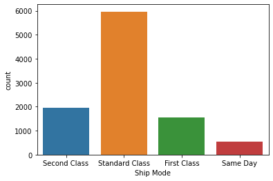

```python
# Getting how much Ship mode is used
sns.countplot(x='Ship Mode', data=df )
```

##### This means that standard class are highly used for shipping mode

```python
df['Segment'].value_counts()
```

```
Consumer       5191
Corporate      3020
Home Office    1783
Name: Segment, dtype: int64
```

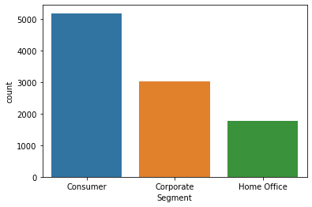

```python
sns.countplot( x = "Segment" , data = df ,)
```

##### Highest sales are made to Consumer segments

##### This means that consumer segment is more attracted towards the product

```python
df['Country'].value_counts()
```

```
United States    9994
Name: Country, dtype: int64
```

##### All sales are basically to US only , so this should not be further evaluated

```python
### THERE ARE MANY CITIES TO WHICH SALES ARE MADE BUT , WE ARE INCLUDING ONLY THOSE WHICH ARE USED GRATER THAN 100
df['City'].value_counts().head(13)
```

```
New York City    915
Los Angeles      747
Philadelphia     537
San Francisco    510
Seattle          428
Houston          377
Chicago          314
Columbus         222
San Diego        170
Springfield      163
Dallas           157
Jacksonville     125
Detroit          115
Name: City, dtype: int64
```

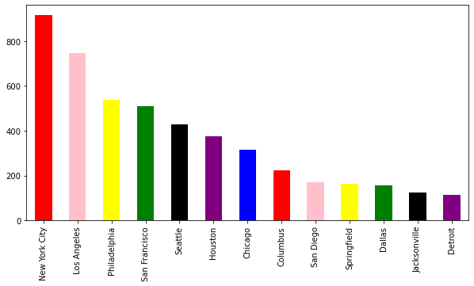

```python
df['City'].value_counts().head(13).plot(kind='bar',color= ["red","pink","yellow","green","black","purple","blue"] ,figsize=(10,5))
plt.show()
```

##### This shows how Newyork is in the first place to sales , this means that to rise the profit more efforts can be done in NewYork or

##### More advertisement should be done in new york to make it a market hub

```python
df['Region'].value_counts()
```

```
West       3203
East       2848
Central    2323
South      1620
Name: Region, dtype: int64
```

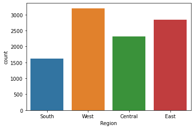

```python
sns.countplot(x = 'Region', data = df )
```

##### This clearly shows that largest sales are made only to WEST and EAST region . So we should

##### devote our promotional strategies in that .

```python
df['Category'].value_counts()
```

```
Office Supplies    6026
Furniture          2121
Technology         1847
Name: Category, dtype: int64
```

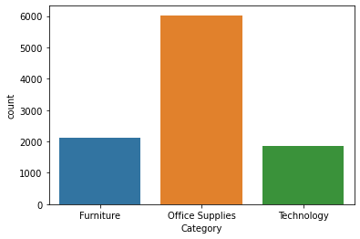

```python
sns.countplot( x = 'Category', data = df )
```

##### We need to attract more office supplies instead of Furniture and technology aspects as our office supplies are

##### liked by many citizens

```python
df['Sub-Category'].value_counts()
```

```
Binders        1523
Paper          1370
Furnishings     957
Phones          889
Storage         846
Art             796
Accessories     775
Chairs          617
Appliances      466
Labels          364
Tables          319
Envelopes       254
Bookcases       228
Fasteners       217
Supplies        190
Machines        115
Copiers          68
Name: Sub-Category, dtype: int64
```

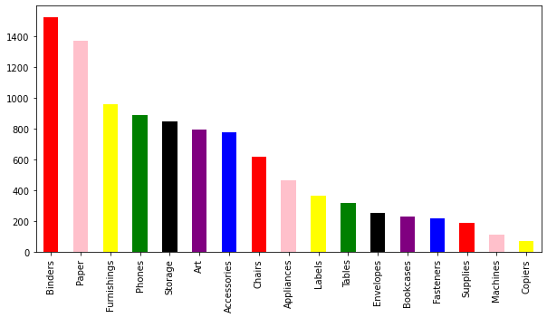

```python
df['Sub-Category'].value_counts().plot(kind = 'bar', figsize=(10,5,),color=["red","pink","yellow","green","black","purple","blue"])
plt.show()
```

##### Can visualize which subgatory performs well

```python
## Now move towards some numerical variables
df.select_dtypes(include= [np.number]).columns
```

```
Index(['Postal Code', 'Sales', 'Quantity', 'Discount', 'Profit'], dtype='object')
```

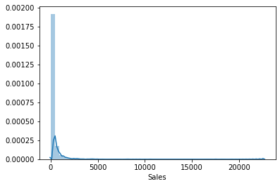

```python
## Have a look at how numerical columns behave by knowing there distribution
sns.distplot(df['Sales'] )
```

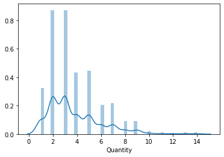

```python
sns.distplot(df['Quantity'] )
```

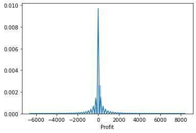

```python
sns.distplot(df['Profit'] )
```

# Bivariate Analysis

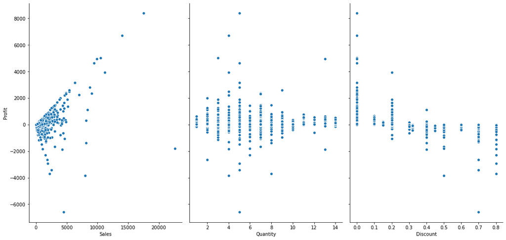

```python
sns.pairplot(df[0:10000], x_vars=['Sales','Quantity','Discount'], y_vars='Profit',
             size=7, aspect=0.7, kind='scatter')
```

#### This shows that when the sales are in larger quantity , then only the company are making profits ,

#### In a smaller quantities of sale , company is having a loss

#### While Quantity sold and Discount doesn't depict increasing profits

```python
df.corr()
```

|  | Postal Code | Sales | Quantity | Discount | Profit |
| --- | --- | --- | --- | --- | --- |
| Postal Code | 1.000000 | -0.023854 | 0.012761 | 0.058443 | -0.029961 |
| Sales | -0.023854 | 1.000000 | 0.200795 | -0.028190 | 0.479064 |
| Quantity | 0.012761 | 0.200795 | 1.000000 | 0.008623 | 0.066253 |
| Discount | 0.058443 | -0.028190 | 0.008623 | 1.000000 | -0.219487 |
| Profit | -0.029961 | 0.479064 | 0.066253 | -0.219487 | 1.000000 |

#### Only profit and Sales are showing some amount of correlation ,

#### Rest we are unable to find any high correlation among Discount and Quantity sold ,

#### Discount and profits , Discounts and Sales .

#### This means that we are unable to covert our discounts into a useful element

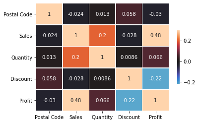

```python
# Compute the correlation matrix
corr = df.corr()
sns.heatmap(corr, vmax=.3, center=0, linewidths=.5, cbar_kws={"shrink": .5} , annot = True)
```

#### Same as above stated , only Profit and Sales have some amount of correlation , rest numeric variables doesn't have .

```python
### Let us see which ship mode lead to highest profits and corresponding quantity
ship_mode =df.groupby('Ship Mode')["Profit" ,"Quantity"].sum()
print(ship_mode)
```

```
                     Profit  Quantity
Ship Mode
First Class      48969.8399      5693
Same Day         15891.7589      1960
Second Class     57446.6354      7423
Standard Class  164088.7875     22797
```

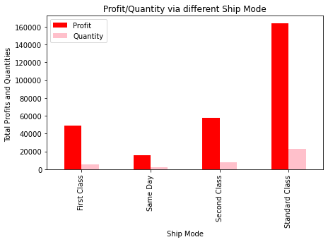

```python
ship_mode.plot( kind = "bar" , color=['red','pink'],figsize=(7,4))
plt.ylabel("Total Profits and Quantities ")
plt.title(" Profit/Quantity via different Ship Mode ")
plt.legend()
plt.show()
```

#### This shows standard class gives Highest profits and Also Higher quantity is shipped from Standard class only

```python
### Let us see which segment mode lead to highest profits and corresponding quantity
Segment =df.groupby('Segment')["Profit" ,"Quantity"].sum()
print(Segment)
```

```
                  Profit  Quantity
Segment
Consumer     134119.2092     19521
Corporate     91979.1340     11608
Home Office   60298.6785      6744
```

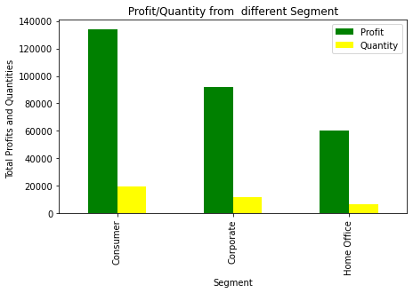

```python
Segment.plot( kind= "bar" , color=['green','yellow'],figsize=(7,4))
plt.ylabel("Total Profits and Quantities ")
plt.title(" Profit/Quantity from  different Segment ")
plt.legend()
plt.show()
```

```python
### Let us see which State  lead to highest profits and corresponding quantity
State =df.groupby('State')["Profit" ,"Quantity"].sum()
print(State)
```

```
                          Profit  Quantity
State
Alabama                5786.8253       256
Arizona               -3427.9246       862
Arkansas               4008.6871       240
California            76381.3871      7667
Colorado              -6527.8579       693
Connecticut            3511.4918       281
Delaware               9977.3748       367
District of Columbia   1059.5893        40
Florida               -3399.3017      1379
Georgia               16250.0433       705
Idaho                   826.7231        64
Illinois             -12607.8870      1845
Indiana               18382.9363       578
Iowa                   1183.8119       112
Kansas                  836.4435        74
Kentucky              11199.6966       523
Louisiana              2196.1023       156
Maine                   454.4862        35
Maryland               7031.1788       420
Massachusetts          6785.5016       491
Michigan              24463.1876       946
Minnesota             10823.1874       331
Mississippi            3172.9762       221
Missouri               6436.2105       252
Montana                1833.3285        56
Nebraska               2037.0942       136
Nevada                 3316.7659       168
New Hampshire          1706.5028       127
New Jersey             9772.9138       454
New Mexico             1157.1161       151
New York              74038.5486      4224
North Carolina        -7490.9122       983
North Dakota            230.1497        30
Ohio                 -16971.3766      1759
Oklahoma               4853.9560       247
Oregon                -1190.4705       499
Pennsylvania         -15559.9603      2153
Rhode Island           7285.6293       199
South Carolina         1769.0566       172
South Dakota            394.8283        42
Tennessee             -5341.6936       681
Texas                -25729.3563      3724
Utah                   2546.5335       219
Vermont                2244.9783        50
Virginia              18597.9504       893
Washington            33402.6517      1883
West Virginia           185.9216        18
Wisconsin              8401.8004       463
Wyoming                 100.1960         4
```

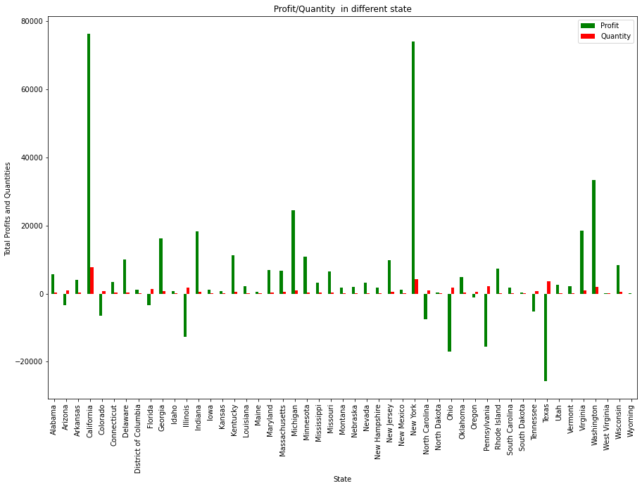

```python
State.plot( kind= "bar" , color=['green','red'],figsize=(15,10))
plt.ylabel("Total Profits and Quantities ")
plt.title(" Profit/Quantity  in different state ")
plt.legend()
plt.show()
```

##### This shows that New York and California basically contribute highest profits as well as quantity

##### Many countries produces negative profits or losses , we should contribute our quantity maximum to these two states

##### As they are liking the products most .

##### We should avoid our products sending to "texas" as it gives the most negative profit with most quantity

```python
City = df.groupby('City')['Profit','Quantity'].sum()
print(City)
```

```
                Profit  Quantity
City
Aberdeen        6.6300         3
Abilene        -3.7584         2
Akron        -186.6356        65
Albuquerque   634.0881        65
Alexandria    318.6183        84
...                ...       ...
Woonsocket     78.6791        15
Yonkers      2767.7557        57
York         -102.1692        19
Yucaipa        13.2080         5
Yuma         -465.9909        22

[531 rows x 2 columns]
```

#### We can also make our decisions on the basis of Cities , but first we should make our decision on the basis of States,

#### Then if the results will not improves then we can further analyse it

```python
Region = df.groupby('Region')["Profit","Quantity"].sum()
print(Region)
```

```
              Profit  Quantity
Region
Central   39706.3625      8780
East      91522.7800     10618
South     46749.4303      6209
West     108418.4489     12266
```

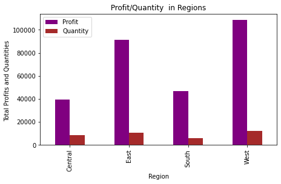

```python
Region.plot( kind ="bar" ,  color = ['purple','Brown'] , figsize= (7,4))
plt.ylabel("Total Profits and Quantities ")
plt.title(" Profit/Quantity  in Regions ")
plt.legend()
plt.show()
```